# Examining the role of transcription and post-transcriptional modifications on mediating intragenomic conflict in honey bees: identification and differential expression of lincRNAs

Lindsay Clark, HPCBio, Roy J. Carver Biotechnology Center, University of Illinois, Urbana-Champaign

Modified for publication by Sean Bresnahan, Huck Institutes of the Life Sciences, Pennsylvania State University

2022-12-22

## Results files

The “results/lincRNA_results” folder contains results from this analysis:

- `raw_counts_txpt_info_2022-07-06.xlsx` contains genomic coordinates of each lincRNA transcript, as well as raw read counts in each sample.
- `lincRNA_sequence_2022-07-06.fa` contains the sequence of each transcript.
- `filtered_logCPM_lincRNA_2022-07-07.xlsx` contains logCPM (log-2 counts-per-million) values for transcripts after filtering.
- `differential_lincRNA_expression_results_2022-07-06.xlsx` contains results of differential expression analysis.

Additionally, all scripts and code for the full analysis are available at https://github.com/sbresnahan/allele-specific-transcription-and-m6A.

## Study design

This study seeks to use transcriptome data to understand behavioral differences between non-aggressive and aggressive honey bees. Two crosses were made. Cross A had AHB as the female parent (SRR14654188) and EHB as the male parent (SRR14654189). Cross B had EHB as the female parent (SRR14654186) and AHB as the male parent (SRR14654187). Three or more aggressive bees and three or more non-aggressive bees (labeled C and T) were collected from each cross. Twelve head and abdomen samples, spanning multiple batches over the course of a year, were ultimately analyzed, with three samples per experimental group. RNA samples were sequenced with Oxford Nanopore Technology direct RNA sequencing on a FLO-MIN106 flowcell.

In this report I describe the detection of lincRNAs and their differential expression.

## Sample processing

FAST5 files from all samples were processed with Guppy 5.0.16 using the `rna_r9.4.1_70bps_hac.cfg` configuration (Oxford Nanopore Technologies) for base calling on a GPU. FASTQ files labeled “pass” were concatenated together to generate one FASTQ per sample. [Minimap 2.21](https://github.com/lh3/minimap2)[^1] was used for alignment to the [*Apis mellifera* HAv3.1 reference genome](https://www.ncbi.nlm.nih.gov/genome/48?genome_assembly_id=403979) (plus common viral genomes) in splice-aware mode with a kmer length of 14, using the published gene annotation to guide alignment. [SAMtools 1.12](https://github.com/samtools/samtools)[^2] was used to sort and index the resulting BAM files. [Flair 1.5](https://github.com/BrooksLabUCSC/flair)[^3] was then used to convert BAM files to BED format and correct intron-exon junctions based on the published annotation, then call isoforms across all samples. These isoforms included published transcripts and genes as well as novel transcripts and genes.

The `flair quantify` command was then used to quantify abundance of each transcript in each sample.

## Identification of long intergenic non-coding RNAs (lincRNAs)

Of the 31,475 transcripts output by Flair[^4], 451 were already annotated as long non-coding RNAs (lncRNAs) in the NCBI GCF_003254395.2_Amel_HAv3.1 annotation, while 12 were for genes annotated as ribosomal RNA (rRNA) or small nuclear RNA (snRNA), and 17,880 were for protein-coding genes. Although snoRNAs, miRNAs, tRNAs, and guide RNAs were annotated in the reference genome, Flair did not output transcripts for any of these.

Transcripts were defined as “intergenic” if they had no overlap with any annotated protein-coding, rRNA, miRNA, snRNA, snoRNA, tRNA, or guide RNA gene; 3,908 transcripts were considered intergenic by this measure. Additionally, 77 transcripts were on the mitochondrial genome (including transcripts matching gene NC_037641.1:1186000). Transcripts were retained for further analysis if they were non-mitochondrial, intergenic, and were at least 200 nucleotides in length, leaving 3806 transcripts for further analysis, including 6 transcripts that were later removed for being viral in origin.

The `findORFs` function in the ORFhunterR[^5] R package was used to identify putative open reading frames (ORFs) and their lengths. However, 142 of the 165 annotated lncRNAs that were analyzed had putative ORFs using this method, so this information was ignored in favor of other approaches for determining if transcripts were protein-coding. Using [CPC2](http://cpc2.gao-lab.org/batch.php)[^6], 61 out of 3806 transcripts were determined to have coding potential. Additionally, BLASTX (from BLAST+ v2.10.1) was used to align transcripts to the Uniprot and Swiss-Prot combined database (from a June 2020 mirror) under default parameters. Using a cutoff E value of 0.001, 120 transcripts aligned to a known protein sequence. Lastly, gene sequences for all annotated snRNA, snoRNA, miRNA, tRNA, rRNA, and guide RNAs were extracted from the GCF_003254395.2_Amel_HAv3.1 reference sequence. Since there were no annotated 7SL RNA genes in the reference, I used sequences NR_001992.2 and NR_037753.2 from *Drosophila melanogaster* to represent those. I then aligned the putative lincRNA transcripts to all of these other non-coding RNAs using discontiguous megablast (from BLAST+ v2.10.1) under default parameters, finding six transcripts aligning very strongly to rRNA genes.

Altogether, 3642 transcripts were retained as lincRNAs for being non-mitochondrial, non-viral, intergenic, at least 200 nt long, not predicted to have coding potential by CPC2, not aligning to known proteins, and not aligning to other non-coding RNAs. This is an increase over the 3048 lincRNA transcripts identified prior to fixing the Flair bug. Tallies of annotated and novel lincRNAs and their corresponding genes are listed in Table 1.

Table 1. Tallies of annotated and unannotated lincRNAs after filtering.

| Gene_type | Genes | Annotated_lncRNAs | Annotated_pseudogene_RNAs | Novel_RNAs |
| --- | --- | --- | --- | --- |
| Annotated | 219 | 158 | 1 | 116 |
| Novel | 2970 | 0 | 0 | 3367 |

## QC on read counts

Out of the 3642 lincRNA transcripts identified, Flair output read counts for 3640 of them. The proportion of reads mapping to lincRNAs varied among samples, with T samples having slightly lower proportions than C samples (P = 0.055). At a gross scale the total number of lincRNA reads followed the total library size (Fig. 2; see library sizes in previous reports).

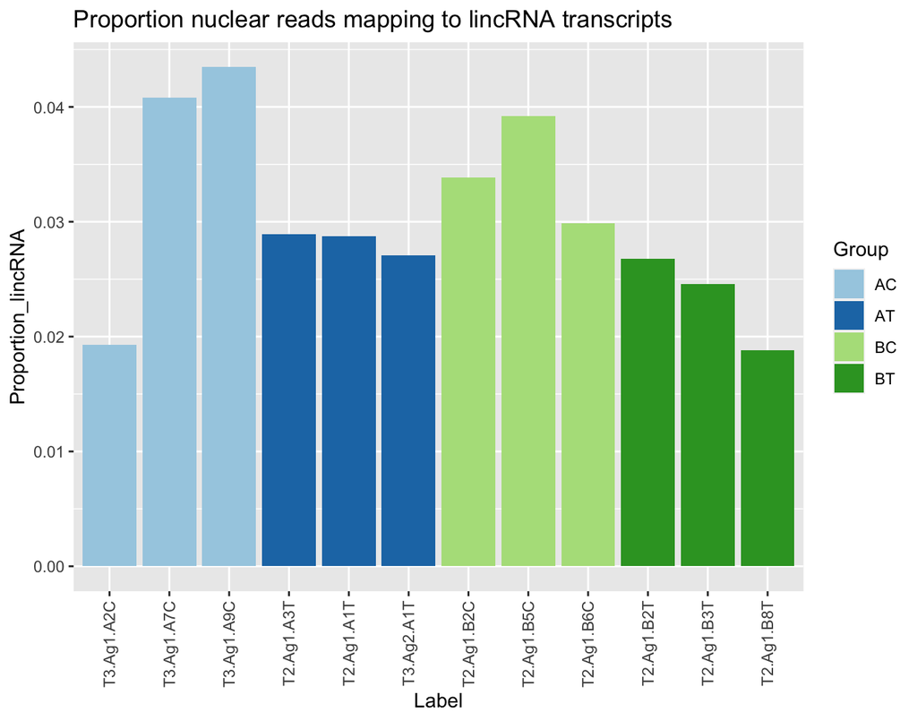

Fig. 1. Proportion of reads mapping to lincRNAs, out of total reads mapping to the nuclear genome. Reads mapping to mitochondrial or viral genomes were excluded.

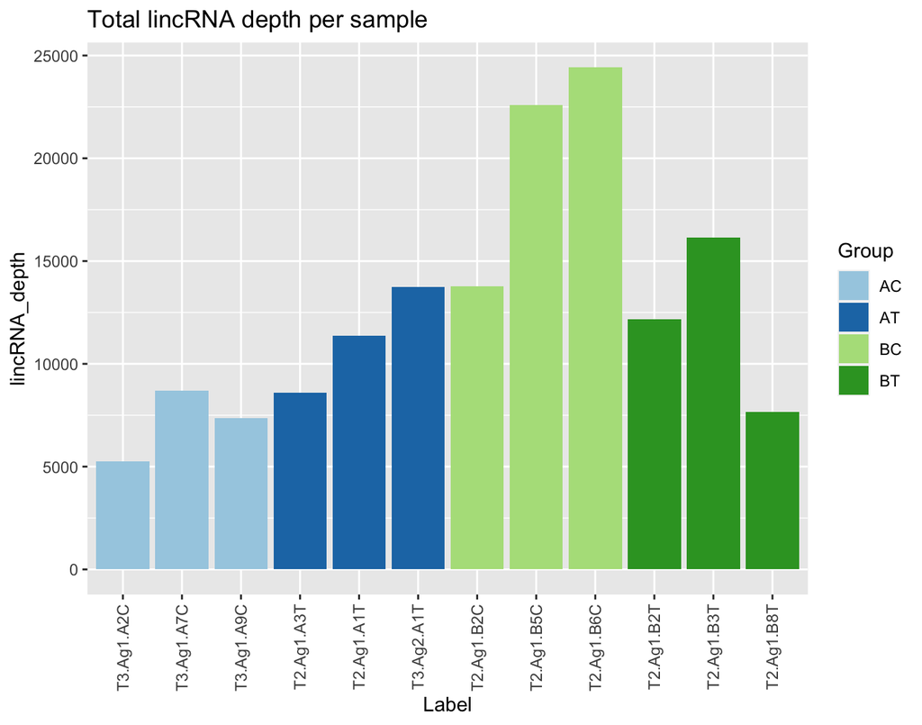

Fig. 2. Total number of reads mapping to lincRNAs in each sample.

## Normalization and filtering

When comparing expression levels, the numbers of reads per transcript need to be normalized not only because of the differences in total number of reads, but because there could be differences in RNA composition such that the total number of reads would not be expected to be the same. The TMM (trimmed mean of M values) normalization[^7] in the [edgeR](https://bioconductor.org/packages/release/bioc/html/edgeR.html) package[^8] uses the assumption of *most genes do not change* to calculate a normalization factor for each sample to adjust for such biases in RNA composition. In this dataset, TMM normalization factors fluctuated between 0.84 and 1.3. TMM normalization factors are multiplied by the library size in order to generate the effective library size, where smaller TMM normalization factors indicate more overrepresented genes in the sample. Normalization factors varied among samples but were not particularly associated with experimental group (Fig. 3).

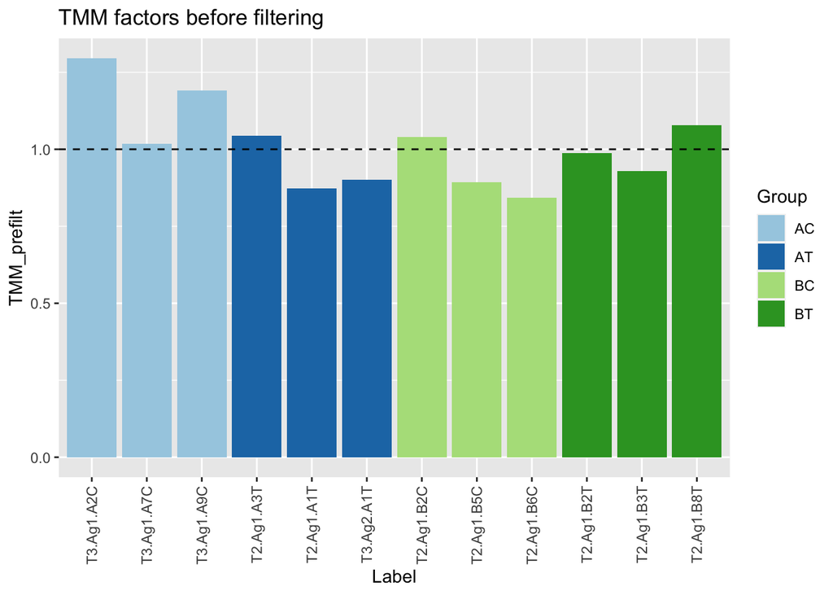

Fig. 3. Normalization factors before filtering

After filtering, TMM normalization was performed again and normalized log2-based count per million values (logCPM) were calculated using edgeR’s[^9] `cpm()` function with `prior.count = 2` to help stabilize fold-changes of extremely low expression genes. TMM normalization factors after filtering are shown in Fig. 5, and compared to pre-filtering values in Fig. 6.

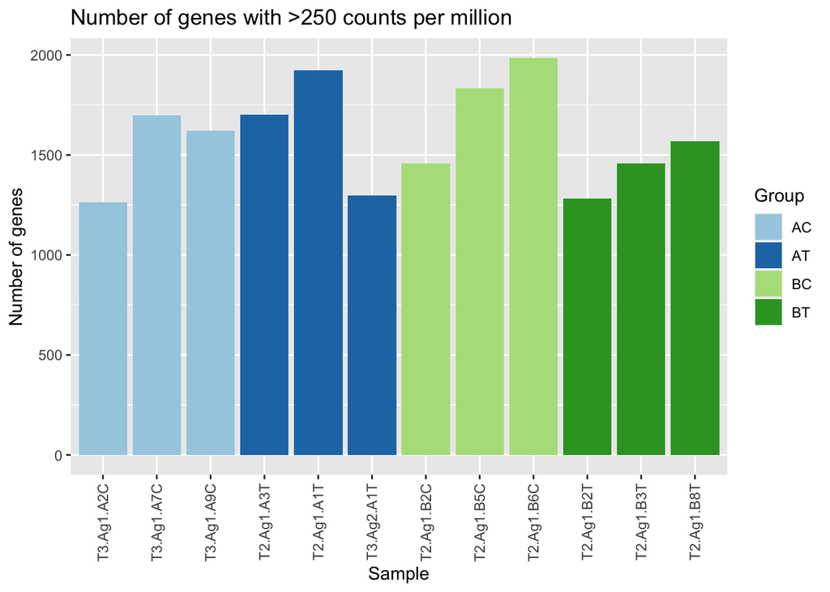

Fig. 4. Number of detected genes passing the filtering threshold in each sample.

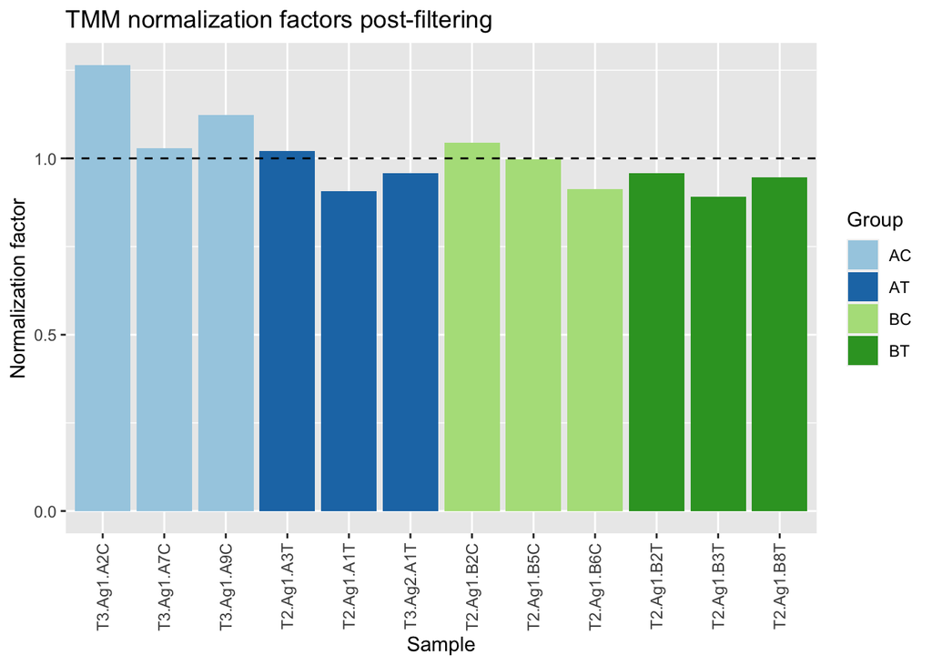

Fig. 5. TMM normalization factors post-filtering.

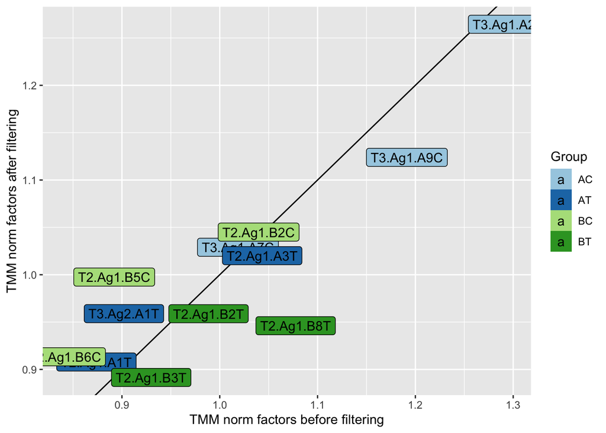

Fig. 6. Comparison of TMM normalization factors before and after filtering.

## Sample clustering

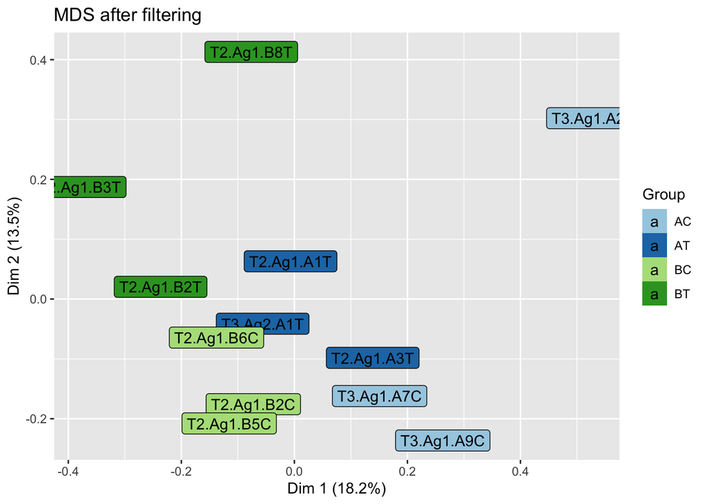

Fig. 7. Multidimensional scaling of samples after filtering, using the top 5000 variable genes between each pair of samples.

## Differential gene expression

Differential gene expression (DE) analysis was performed using the limma-trend method[^11]. Multiple testing correction was done using the False Discovery Rate method[^12]. The model run was:

$Y = Group$

where $Group$ refers to the AC, AT, BC, and BT groups. The following contrasts were then assessed:

- **BT - BC**: Differences between T and C bees from the B cross
- **AT - AC**: Differences between T and C bees from the A cross
- **BC - AC**: Differences between B and A crosses, with C as the baseline
- **BT - AT**: Differences between B and A crosses in T samples
- **(BT + AT) - (BC + AC)**: Differences between T and C bees across both crosses
- **(BT + BC) - (AT + AC)**: Differences between crosses, looking at both C and T
- **(BT - BC) - (AT - AC)**: Interaction effect; differential effect of cross on differences between T and C bees

Numbers of significantly up- and down-regulated genes are shown in Table 2.

Table 2. Number of gene significant for differential expression at FDR < 0.05.

|  | BT - BC | AT - AC | BC - AC | BT - AT | (BT + AT) - (BC + AC) | (BT + BC) - (AT + AC) | (BT - BC) - (AT - AC) |
| --- | --- | --- | --- | --- | --- | --- | --- |
| Down | 1 | 0 | 1 | 4 | 3 | 2 | 0 |
| NotSig | 2409 | 2413 | 2404 | 2408 | 2401 | 2396 | 2415 |
| Up | 5 | 2 | 10 | 3 | 11 | 17 | 0 |

Results for all genes are listed in the file “differential_lincRNA_expression_results_2022-07-06.xlsx”.

## Heatmaps for differential lincRNA expression

Across all of the experimental groups contrasts, a one-way ANOVA was run in limma, identifying 41 significant lincRNAs. These lincRNA were then plotted in a heatmap to summarize gross changes in lincRNA expression across groups. (Fig. 8).

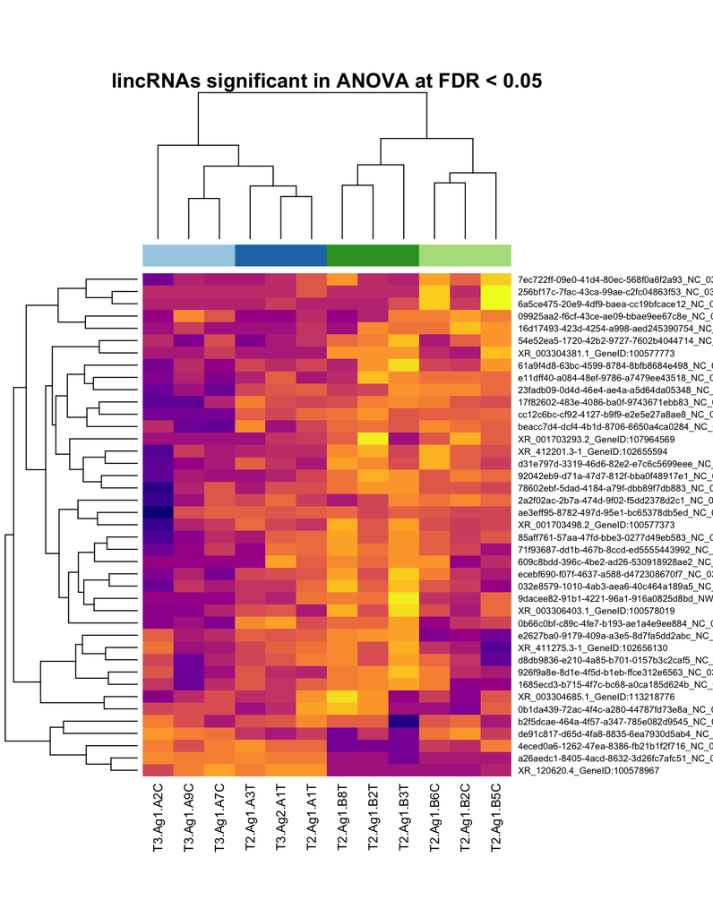

## References

[^1]: Li, H. (2018). Minimap2: pairwise alignment for nucleotide sequences. Bioinformatics, 34:3094-3100. doi:10.1093/bioinformatics/bty191
[^2]: Petr Danecek, James K Bonfield, Jennifer Liddle, John Marshall, Valeriu Ohan, Martin O Pollard, Andrew Whitwham, Thomas Keane, Shane A McCarthy, Robert M Davies, Heng Li (2021). Twelve years of SAMtools and BCFtools. GigaScience, Volume 10, Issue 2, giab008, https://doi.org/10.1093/gigascience/giab008
[^3]: Tang, A.D., Soulette, C.M., van Baren, M.J. et al. Full-length transcript characterization of SF3B1 mutation in chronic lymphocytic leukemia reveals downregulation of retained introns. Nat Commun 11, 1438 (2020). https://doi.org/10.1038/s41467-020-15171-6
[^4]: Tang, A.D., Soulette, C.M., van Baren, M.J. et al. Full-length transcript characterization of SF3B1 mutation in chronic lymphocytic leukemia reveals downregulation of retained introns. Nat Commun 11, 1438 (2020). https://doi.org/10.1038/s41467-020-15171-6
[^5]: Grinev V, Yatskou M, Skakun V, Chepeleva M, Nazarov P (2021). ORFhunteR: Predict open reading frames in nucleotide sequences. R package version 1.2.0.
[^6]: Kang Y. J., Yang D. C., Kong L., Hou M., Meng Y. Q., Wei L., Gao G. 2017. CPC2: a fast and accurate coding potential calculator based on sequence intrinsic features. Nucleic Acids Research 45(Web Server issue): W12–W16.
[^7]: Robinson MD, Oshlack A (2010). A scaling normalization method for differential expression analysis of RNA-seq data. Genome Biology 11, R25.
[^8]: Robinson MD, McCarthy DJ, Smyth GK (2010). “edgeR: a Bioconductor package for differential expression analysis of digital gene expression data.” Bioinformatics, 26(1), 139-140.
[^9]: McCarthy DJ, Chen Y, Smyth GK (2012). “Differential expression analysis of multifactor RNA-Seq experiments with respect to biological variation.” Nucleic Acids Research, 40(10), 4288-4297.
[^10]: Ritchie, M.E., Phipson, B., Wu, D., Hu, Y., Law, C.W., Shi, W., and Smyth, G.K. (2015). limma powers differential expression analyses for RNA-sequencing and microarray studies. Nucleic Acids Research 43(7), e47.
[^11]: Chen Y, Lun ATL and Smyth GK. From reads to genes to pathways: differential expression analysis of RNA-Seq experiments using Rsubread and the edgeR quasi-likelihood pipeline [version 2; referees: 5 approved]. F1000Research 2016, 5:1438 (doi: 10.12688/f1000research.8987.2)
[^12]: Benjamini, Y., & Hochberg, Y. (1995). Controlling the false discovery rate: a practical and powerful approach to multiple testing. Journal of the Royal statistical society: series B (Methodological), 57(1), 289-300.